[Imtiaj.](https://imtiajiqbalmahfuj.github.io/index.html#top)

# 🌎 Global Climate Change Risk Index 2022 (INFORM)

### Assessing Global CC Vulnerability, Hazard Exposure, and Coping Capacity through HDX & INFORM Data

[figure not shown]

## 📝 Overview

- 🌋 **Hazard & Exposure** (natural and human-made CC threats)
- 🌾 **Vulnerability** (socio-economic and infrastructural susceptibility)
- 🕊️ **Lack of Coping Capacity** (institutional and emergency response limitations)

This Python-powered visualization reveals global disparities in disaster preparedness and resilience — emphasizing which regions are most exposed to crises and least capable of coping.

## 🛠️ Tools & Technologies

## ⚙️ Methodology

[output not shown]

## Codes

```python
import pandas as pd
import geopandas as gpd
import matplotlib.pyplot as plt
```

```python
path = "Data/inform-cc-brochure-data.xlsx"
data = pd.read_excel(path, skiprows = [0,1,2,3])
data.columns
```

```python
df = data[["Country","INFORM CC Risk Index 2022"]]
df
```

|  | Country | INFORM CC Risk Index 2022 |
| --- | --- | --- |
| 0 | Afghanistan | 8.0 |
| 1 | Albania | 2.6 |
| 2 | Algeria | 3.9 |
| 3 | Angola | 4.5 |
| 4 | Antigua and Barbuda | 2.0 |
| ... | ... | ... |
| 186 | Venezuela | 4.2 |
| 187 | Viet Nam | 3.7 |
| 188 | Yemen | 8.1 |
| 189 | Zambia | 4.2 |
| 190 | Zimbabwe | 4.4 |

191 rows × 2 columns

```python
world = gpd.read_file("Data/World_Map.shp")
world
```

|  | NAME | geometry |
| --- | --- | --- |
| 0 | Antigua and Barbuda | MULTIPOLYGON (((-61.68667 17.02444, -61.73806 ... |
| 1 | Algeria | POLYGON ((2.96361 36.80222, 2.98139 36.80694, ... |
| 2 | Azerbaijan | MULTIPOLYGON (((45.08332 39.76804, 45.26639 39... |
| 3 | Albania | POLYGON ((19.43621 41.02106, 19.45055 41.06, 1... |
| 4 | Armenia | MULTIPOLYGON (((45.57305 40.63249, 45.52888 40... |
| ... | ... | ... |
| 240 | Saint Barthelemy | POLYGON ((-63.02834 18.01555, -63.03334 18.015... |
| 241 | Guernsey | POLYGON ((-2.59083 49.42249, -2.59722 49.42249... |
| 242 | Jersey | POLYGON ((-2.015 49.21416, -2.02111 49.17722, ... |
| 243 | South Georgia South Sandwich Islands | MULTIPOLYGON (((-27.32584 -59.42722, -27.29806... |
| 244 | Taiwan | MULTIPOLYGON (((121.57639 22.00139, 121.57027 ... |

245 rows × 2 columns

```python
gdf = pd.merge(world, df, how="left", left_on="NAME", right_on="Country")
gdf
```

|  | NAME | geometry | Country | INFORM CC Risk Index 2022 |
| --- | --- | --- | --- | --- |
| 0 | Antigua and Barbuda | MULTIPOLYGON (((-61.68667 17.02444, -61.73806 ... | Antigua and Barbuda | 2.0 |
| 1 | Algeria | POLYGON ((2.96361 36.80222, 2.98139 36.80694, ... | Algeria | 3.9 |
| 2 | Azerbaijan | MULTIPOLYGON (((45.08332 39.76804, 45.26639 39... | Azerbaijan | 5.8 |
| 3 | Albania | POLYGON ((19.43621 41.02106, 19.45055 41.06, 1... | Albania | 2.6 |
| 4 | Armenia | MULTIPOLYGON (((45.57305 40.63249, 45.52888 40... | Armenia | 5.3 |
| ... | ... | ... | ... | ... |
| 240 | Saint Barthelemy | POLYGON ((-63.02834 18.01555, -63.03334 18.015... | NaN | NaN |
| 241 | Guernsey | POLYGON ((-2.59083 49.42249, -2.59722 49.42249... | NaN | NaN |
| 242 | Jersey | POLYGON ((-2.015 49.21416, -2.02111 49.17722, ... | NaN | NaN |
| 243 | South Georgia South Sandwich Islands | MULTIPOLYGON (((-27.32584 -59.42722, -27.29806... | NaN | NaN |
| 244 | Taiwan | MULTIPOLYGON (((121.57639 22.00139, 121.57027 ... | NaN | NaN |

245 rows × 4 columns

```python
fig, ax = plt.subplots(figsize = (10,5))
gdf.plot(ax = ax,
         column = "INFORM CC Risk Index 2022",
         cmap="plasma",
         linewidth=0.5,
         edgecolor="white",
         legend=True,
         legend_kwds={"label": "INFORM CC Risk Index 2022", "shrink": 0.5},
         missing_kwds={
             "color": "lightgray",     # countries with no data
             "edgecolor": "white",
             #"hatch": "...",           # optional hatch pattern
             "label": "No data"
         }
        )

ax.set_title("GlobalClimate Change Risk Index 2022", fontsize=16)
ax.axis("off")
```

[output not shown]

```python
missing = df[~df["Country"].isin(world["NAME"])]
missing["Country"].unique()
```

[output not shown]

```python
world["NAME"].unique()
```

```python
replace_dict = {
    'Iran': 'Iran (Islamic Republic of)',
    'Russian Federation' : 'Russia',
    'Tanzania': 'United Republic of Tanzania',
    'Türkiye': 'Turkey',
    'United States of America': 'United States'
}
```

```python
df["Country"] = df["Country"].replace(replace_dict)
df["Country"].unique()
```

```python
gdfn = pd.merge(world, df, how="left",left_on="NAME", right_on="Country")
gdfn
```

[output not shown]

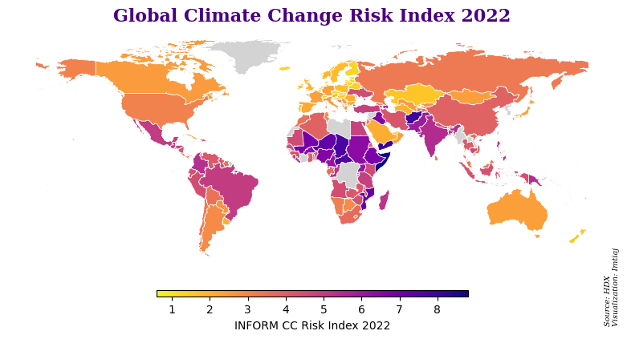

```python
fig, ax = plt.subplots(figsize = (10,5))
gdfn.plot(ax = ax,
          column = "INFORM CC Risk Index 2022",
          cmap="plasma_r",
          linewidth=0.5,
          edgecolor="white",
          legend=True,
          legend_kwds={"label": "INFORM CC Risk Index 2022",
                       "orientation": "horizontal",
                       "pad": 0.05, # space between map and colorbar
                       "shrink": 0.5,
                       "aspect": 50, # controls thickness of the colorbar
                      },
          missing_kwds={
             "color": "lightgray",     # countries with no data
             "edgecolor": "white",
             #"hatch": "...",           # optional hatch pattern
             "label": "No data"
         }
        )

ax.set_title("Global Climate Change Risk Index 2022",
             fontsize=16,
             fontname= 'serif',#'monospace',
             weight='semibold',
             stretch='expanded',
             color = "indigo"
            )

ax.axis("off")

ax.text(x=.98, y=-.2,
        transform = ax.transAxes,
        s="Source: HDX\nVisualization: Imtiaj",
        rotation='vertical',
        style='italic',
        fontname='serif',
        size='x-small',
        stretch='expanded'
       )

plt.savefig("Climate Change Risk Index 2022", dpi = 300 , bbox_inches = "tight")
```

```python
#?gdfn.plot
#?ax.text
#?plt.subplots
#?plt.savefig
```

## 📊 Results & Insights

This map highlights how **fragile governance, conflict, and climate vulnerability** intersect to shape global disaster risk patterns.  
It serves as an analytical and visual tool for policymakers, researchers, and planners in humanitarian and environmental risk assessment.

[figure not shown]

## 💡 Key Takeaways

- INFORM bridges **humanitarian data and geospatial science** for better disaster preparedness.
- Areas with **weak infrastructure or governance** are most vulnerable to crises.
- Mapping such risks helps direct **resilience-building and resource allocation** effectively.

## 🔖 Tags

`GIS` `Geospatial` `Python` `GeoPandas` `Matplotlib` `HDX` `INFORM Risk`  
`Global Risk` `Humanitarian Mapping` `Spatial Data Science` `Data Visualization` `Disaster Risk`

## 🧭 License

This project is intended for **educational and research purposes**.  
Please cite the author and data sources if used for academic or professional work.

## 🌍 Author

**Imtiaj Iqbal**  
📍 Rajshahi, Bangladesh  
🔗 imtiajiqbal.github.io  
🌱 Exploring GIS, Remote Sensing & Climate Risk Analytics